# How Men and Women Differ in the Eyes of Philosophy

Sarah Kurihara

2/6/2022

### Introduction

In this project, we explore the differences between men and women in various philoscophical schools of thought. Using philosophical texts from 13 schools spanning over 2000 years (350 BC - 1985), we can begin to better understand how men and women have been discussed historically through to the modern day.

First, we import the data.

[output not shown]

Original Data Set

| title | author | school | sentence_spacy | original_publication_date | sentence_length |
| --- | --- | --- | --- | --- | --- |
| Plato - Complete Works | Plato | plato | What’s new, Socrates, to make you leave your usual haunts in the Lyceum and spend your time here by the king archon’s court? | -350 | 125 |
| Plato - Complete Works | Plato | plato | Surely you are not prosecuting anyone before the king archon as I am? | -350 | 69 |
| Plato - Complete Works | Plato | plato | The Athenians do not call this a prosecution but an indictment, Euthyphro. | -350 | 74 |
| Plato - Complete Works | Plato | plato | What is this you say? | -350 | 21 |
| Plato - Complete Works | Plato | plato | Someone must have indicted you, for you are not going to tell me that you have indicted someone else. | -350 | 101 |
| Plato - Complete Works | Plato | plato | But someone else has indicted you? | -350 | 34 |

Next, we remove stop words. We also include custom stop words from old english that were frequently used in the Stoicism school of thought. We also be sure to remove “man” and “men” from the stop words lists as this will be necessary for future analysis. You can see how the first sentenance in table 1 is repeated multiple times with each row representing a single (important) word from that sentance

| title | author | school | original_publication_date | sentence_length | sentence_lowered | word |
| --- | --- | --- | --- | --- | --- | --- |
| Plato - Complete Works | Plato | plato | -350 | 125 | what’s new, socrates, to make you leave your usual haunts in the lyceum and spend your time here by the king archon’s court? | socrates |
| Plato - Complete Works | Plato | plato | -350 | 125 | what’s new, socrates, to make you leave your usual haunts in the lyceum and spend your time here by the king archon’s court? | leave |
| Plato - Complete Works | Plato | plato | -350 | 125 | what’s new, socrates, to make you leave your usual haunts in the lyceum and spend your time here by the king archon’s court? | usual |
| Plato - Complete Works | Plato | plato | -350 | 125 | what’s new, socrates, to make you leave your usual haunts in the lyceum and spend your time here by the king archon’s court? | haunts |
| Plato - Complete Works | Plato | plato | -350 | 125 | what’s new, socrates, to make you leave your usual haunts in the lyceum and spend your time here by the king archon’s court? | lyceum |
| Plato - Complete Works | Plato | plato | -350 | 125 | what’s new, socrates, to make you leave your usual haunts in the lyceum and spend your time here by the king archon’s court? | spend |

# Top N Words

Top words used by each 13 schools of thought

| school | word | n | total |
| --- | --- | --- | --- |
| analytic | true | 3055 | 379679 |
| aristotle | man | 4012 | 398825 |
| capitalism | price | 2328 | 204725 |
| communism | labour | 3305 | 180751 |
| continental | madness | 2283 | 364726 |
| empiricism | ideas | 3486 | 201175 |
| feminism | woman | 2828 | 194031 |
| german_idealism | concept | 4258 | 418826 |
| nietzsche | man | 1029 | 98947 |
| phenomenology | world | 4295 | 245627 |
| plato | man | 2076 | 223310 |
| rationalism | god | 3283 | 211230 |
| stoicism | man | 302 | 17278 |

From a quick glance at the top words, we can see that “man” is **the** top word for 4 of the 13 schools!

One should note, that for the purposes of this analysis, we left in “man” and “men” despite them being present in the `stop_words` list.

# Term Frequency using TF-IDF

However, just because a term appears many times in a document does not mean these words are “distinctive”. Instead, we can use TF-IDF to identify the unique words that are most characteristic of a book when compared to other books.

Term Frequency (TF) and Inverse Document Frequency (IDF) are two particular approaches that allow us to identify the top words among a corpus (collection) of documents. Using the `bind_tf_idf` function, we can now identify the top words for each school of thought, relative to the other schools of thought.

A visual representnation of the top 10 words using TF-IDF reveals many more interesting words for each school of thought.

```
## # A tibble: 245,502 x 6
## # Groups:   school [13]
##    school          word                n      tf   idf  tf_idf
##    <chr>           <chr>           <int>   <dbl> <dbl>   <dbl>
##  1 nietzsche       zarathustra       589 0.00595 1.47  0.00873
##  2 phenomenology   dasein           1634 0.00665 1.18  0.00784
##  3 german_idealism determinateness  1305 0.00312 1.87  0.00583
##  4 communism       capitalist        843 0.00466 1.18  0.00550
##  5 stoicism        hast               83 0.00480 0.956 0.00459
##  6 stoicism        mayest             41 0.00237 1.87  0.00444
##  7 stoicism        dost               65 0.00376 1.18  0.00443
##  8 phenomenology   sein              737 0.00300 1.47  0.00440
##  9 communism       labour           3305 0.0183  0.167 0.00305
## 10 analytic        counterfactual    449 0.00118 2.56  0.00303
## # … with 245,492 more rows
```

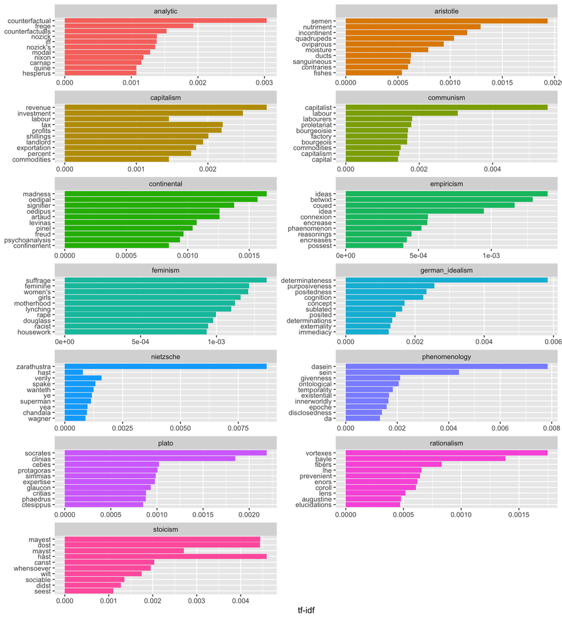

Many of these words are not used in everyday language, so we pull some sentences at random to better understand how they are used in context. A little research has helped explain that these are not errors and that the algorithm is working.

- semen (aristotle): “Aristotle holds that semen is nutriment in its final stage of concoction before it becomes part of the body. Hence, blood, before it turns into flesh, bones, etc., first turns into semen” [link](https://en.wikipedia.org/wiki/Vital_heat)
- dasein (phenomenology): “To ensure that we do not fall into Cartesian language, Heidegger suggests a new term (the first of many). Dasein (literally,”being-there“) is the name of this being from whose perspective the world is being described. Dasein is not a consciousness or a mind, nor is it a person. It is not distinguished from the world of which it is aware. It is inseparable from that world. Dasein is, simply,”Being-in-the-World," which Heidegger insists is a “unitary phenomenon” (not being the world). Thus, phenomenology becomes ontology (the nature of being) as well." [link](https://science.jrank.org/pages/10640/Phenomenology-Martin-Heidegger.html)
- vortices (rationalism) : “A depiction of Rene Descartes’ vortices. In his theory, the entire universe was filled with elements of different sizes which shifted around each other. At the center is the sun, which is made up of the smallest kind of element and the bigger ones sift out and circle around it.” [link](https://www.loc.gov/collections/finding-our-place-in-the-cosmos-with-carl-sagan/articles-and-essays/modeling-the-cosmos/physical-astronomy-for-the-mechanistic-universe)

Sentences with most common words used

| title | school | word | sentence_lowered |
| --- | --- | --- | --- |
| A Treatise Of Human Nature | empiricism | ideas | it is usual with mathematicians, to pretend, that those ideas, which are their objects, are of so refined and spiritual a nature, that they fall not under the conception of the fancy, but must be comp… |
| Plato - Complete Works | plato | socrates | when socrates then also argues that knowledge of names is an unimportant thing, he can be taken to speak with the authority not just of philosophy but even of etymological science itself as an insider… |
| Capital | communism | capitalist | what is it that makes such men as roscher account for the origin of surplus value, by a mere rechauff of the more of less plausible excuses by the capitalist, for his appropriation of surplus value? |
| Plato - Complete Works | plato | socrates | i don’t know about that, socrates. |
| Aristotle - Complete Works | aristotle | semen | it is the nature of those creatures which do not emit semen to remain united a long time until the male element has formed the embryo, as with those insects which copulate. |

## How do sentences discussing men and women differ?

First we create two distinct datasets: (1) Sentences which speak of “men” or “man” and (2) Sentences which speak of “women” or “woman”.

Sentences about Men

| title | sentence_lowered |
| --- | --- |
| Vindication Of The Rights Of Woman | but should it be proved that woman is naturally weaker than man, from whence does it follow that it is natural for her to labour to become still weaker than nature |
| The Second Sex | but in france, men’s disdain for women who ‘sleep around,’ the very men who profit from their favors, paralyzes many women. |
| The Second Sex | the story of the young and capricious girl, rebellious and spoiled, who is tamed by the love of a sensible man is a standard of cheap literature and cinema: it is a clich that flatters both men and wo… |
| The Second Sex | a woman who works hard, who has responsibilities, and who knows how harsh the struggle is against the world’s obstacles needs like the male not only to satisfy her physical desires but also to experie… |
| The Second Sex | the conventionally married woman or one comfortably provided for, supported by a man, having money and relations, is better off: first, she finds ways to have a ‘therapeutic’ abortion much more easily… |

Sentences about Women

| title | sentence_lowered |
| --- | --- |
| Philosophical Troubles | (for example, it need not be true that had she not been a woman, she wouldn’t have gone into acting.) |
| The Second Sex | but the very circumstances that orient the woman toward creation also constitute obstacles she will often be unable to overcome. |
| The Second Sex | the knight is not interested in women: his horse is a treasure of much higher value to him; in the epics, girls are always the ones to make the first step toward young men; once married, they alone ar… |
| The Second Sex | old and ugly women not only are objects without assets but also provoke hatred mixed with fear. |
| The Second Sex | man and love are still far away in the mist of the future; in the present, the little girl seeks activity, autonomy, like her brothers. |

We note that there are many sentences which speak of both male and females in the same sentence. Although a more thorough analysis would include removal of such sentences, for the purposes of this analysis we keep them included in the dataset as we expect that they will have equal impact on both groups of data.

# Sentiment Analysis

## What is the general sentiment (positive or negative) when speaking about these two groups?

In this section, we use the ‘bing’ sentiment lexicon to identify postivie and negative words. We then plot the overall sentiment value for each 250-line chunk of text. 250 was chosen since the average sentence length across all books was 223.

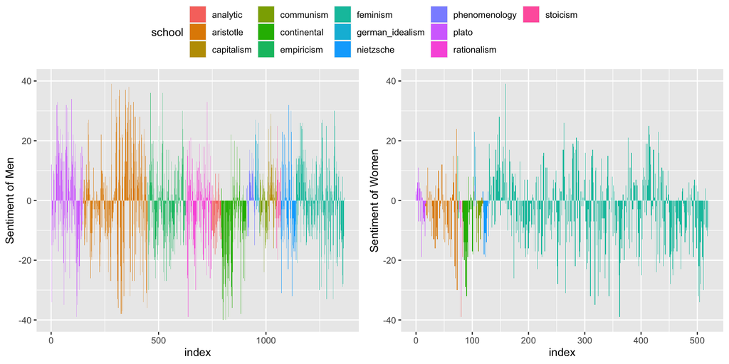

From this analysis, we can see that the positive sentiment is stronger in text about men, where as there are more negative sentiments in text about women. This is likely due to the fact that a lot of feminist writing speak to the inequalities that women face and the suffering caused by dark terms such as “slave” and “rape”.

Additionally, we see that men have a more balanced/equal distribution of positive and negative sentiments.

However, there are some schools of thought with a noticable imbalance, for example, contintental philosophy seems to be more stronly negative for both groups than other schools of thought.

## For each sentiment, what words are being spoken?

We would like to further understand what words are being spoken when the sentence is classified as positive or negative. Below you can see the top 10 words for each group and each sentiment.

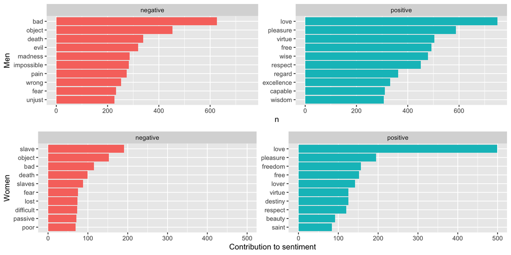

# Conclusion

It can be seen from this simple analysis that societal views of men and women can even be seen when performing simple text analytics on a dataset of historical and philosophical books from over 2000 years. It highlights the systemic issues that women face in society as well as the high pressures that men face to be strong leaders.

Based on this analysis, we can conclude the women and men are, in fact, viewed differently, even in the eyes of philosophy. As we live in the modern age, it would be interesting to pull more text from the current decade to understand if there are positive trends for both men and women. Additional analysis would be needed to determine if there has been a shift and what are the significant terms that has led to this change in mindset.

# References

[Text Mining with R](https://www.tidytextmining.com/index.html)